# Plant-part and environmental gradients shape plant microbiomes

```r
#Multiply each ASV by its distance to shore
rangeF=otu_table(binarysiteF)*sample_data(binarysiteF)$Shore_dist

#Convert 0 to NA
is.na(rangeF) <- rangeF == 0

#Calculate min and max distance to shore
rangespanF = apply(rangeF,2,range.default, na.rm = TRUE)

#Subtract min distance from max distance
rangespanF = rangespanF[2,]-rangespanF[1,]

#Do same thing but log transform range
nozerorangespanF = rangespanF
is.na(nozerorangespanF) <- nozerorangespanF == 0

#Calculate total abundance
abundF = colSums(otu_table(rarPhySeqF))

#Calculate how many samples an ASV is present
occupancyF = colSums(otu_table(phyloseq_standardize_otu_abundance(rarPhySeqF,
    method = "pa")))

#Calculate mean abundance per sample (where present)
meanabundF = otu_table(rarPhySeqF)
is.na(meanabundF) <- meanabundF == 0
meanabundF = rowMeans(meanabundF, na.rm = TRUE)

#Calculate per site habitat diversity (where present)
habpersiteF = cbind(rowSums(otu_table(phyloseq_standardize_otu_abundance(subset_samples(rarPhySeqF, FieldSite=="s1"), method = "pa"))),
                  rowSums(otu_table(phyloseq_standardize_otu_abundance(subset_samples(rarPhySeqF, FieldSite=="s2"), method = "pa"))),
                  rowSums(otu_table(phyloseq_standardize_otu_abundance(subset_samples(rarPhySeqF, FieldSite=="s3"), method = "pa"))),
                  rowSums(otu_table(phyloseq_standardize_otu_abundance(subset_samples(rarPhySeqF, FieldSite=="s4"), method = "pa"))),
                  rowSums(otu_table(phyloseq_standardize_otu_abundance(subset_samples(rarPhySeqF, FieldSite=="s5"), method = "pa"))),
                  rowSums(otu_table(phyloseq_standardize_otu_abundance(subset_samples(rarPhySeqF, FieldSite=="s6"), method = "pa"))),
                  rowSums(otu_table(phyloseq_standardize_otu_abundance(subset_samples(rarPhySeqF, FieldSite=="s7"), method = "pa"))),
                  rowSums(otu_table(phyloseq_standardize_otu_abundance(subset_samples(rarPhySeqF, FieldSite=="s8"), method = "pa"))),
                  rowSums(otu_table(phyloseq_standardize_otu_abundance(subset_samples(rarPhySeqF, FieldSite=="s10"), method = "pa"))))
is.na(habpersiteF) <- habpersiteF == 0
habpersiteF = rowMeans(habpersiteF, na.rm = TRUE)

##################################
## Fungal Abundance Occupancy at Genus Level##
##################################

genus_sitesF = tax_glom(sitesF, taxrank = "Genus")

#Standardize to convert to presence absence and calculate site total
genus_siteF = colSums(otu_table(phyloseq_standardize_otu_abundance(genus_sitesF,
    method = "pa")))

#Convert the ASV table to presence absence in order to calculate range size
genus_binarysiteF = phyloseq_standardize_otu_abundance(genus_sitesF,
    method = "pa")

#Multiply each ASV by its distance to shore
genus_rangeF = otu_table(genus_binarysiteF)*
    sample_data(genus_binarysiteF)$Shore_dist

#Convert 0 to NA
is.na(genus_rangeF) <- genus_rangeF == 0

#Calculate min and max distance to shore
genus_rangespanF = apply(genus_rangeF,2,range, na.rm = TRUE)

#Subtract min distance from max distance
genus_rangespanF = genus_rangespanF[2,] - genus_rangespanF[1,]

#Section 2. Making all plots
######################################################
########## ALL PLOTS AND STATISTICAL TESTS ###########
######################################################

par(mfrow=c(3,2), mar=c(4,5,0.7,0.2))

#####################
#First plot: Bacterial rangespan (PLOT 1, row 1)
#Combine Genus and ASV tables
ranges <- data.frame(Genus=c(rep("Genus", times=length(genus_rangespan)),
                        rep("ASV", times=length(rangespan))),
                 combined_rangespan=c(genus_rangespan, rangespan))

#Set margin size for boxplot
# bactrange
boxplot(combined_rangespan~Genus, horizontal = TRUE, xaxt="n", yaxt="n", medlwd=1.5, lwd=0.8,
    vertical = TRUE, col = "gray48", frame = F, cex.lab = 0.6, ylab="Levels",
    main= "Bacteria", cex.main=0.8,
    xlab="", cex.axis = 0.6, data = ranges)
axis(side=1,labels=F, tck=-0.06)
axis(side=2,labels=c("ASV", "Genus"), cex.axis = 0.6, at=seq(2), tck=-0.06)

#####################
#Second Plot: Fungal rangespan (PLOT 2, row 1)
rangesF <- data.frame(Genus=c(rep("Genus", times=length(genus_rangespanF)),
                             rep("ASV", times=length(rangespanF))),
                     combined_rangespanF=c(genus_rangespanF, rangespanF))

#Set margin size for boxplot
# fungrange
boxplot(combined_rangespanF~Genus, horizontal = TRUE,  xaxt="n", yaxt="n", cex=0.4, medlwd=1.5, main="Fungi", cex.main=0.8, pch=16,
    col = "gray84", frame = F, cex.axis=0.8, ylab="", xlab="", lwd=0.8, data = rangesF)
axis(side=1,labels=F, tck=-0.06)
axis(side=2,labels=F, at=seq(2), tck=-0.06)

#compare ranges between bacteria and fungi genera
t.test(genus_rangespan,genus_rangespanF)

# Welch Two Sample t-test
#
# data:  genus_rangespan and genus_rangespanF
# t = 5.7294, df = 869.79, p-value = 1.389e-08
# alternative hypothesis: true difference in means is not equal to 0
# 95 percent confidence interval:
#   467.2236 954.1336
# sample estimates:
#   mean of x mean of y
# 3757.528  3046.850

#compare ranges between bacteria and fungi ASVs
t.test(rangespan, rangespanF)

# Welch Two Sample t-test
#
# data:  rangespan and rangespanF
# t = 32.062, df = 13235, p-value < 2.2e-16
# alternative hypothesis: true difference in means is not equal to 0
# 95 percent confidence interval:
#   852.2800 963.2758
# sample estimates:
#   mean of x mean of y
# 2077.959  1170.181

#####################
##Plot Bacteria: # of Habitats vs. ASV Range (PLOT 3, row 2)
# bact_habrange
plot(jitter(rangespan,20),jitter(habitats,3), xaxt="n", yaxt="n", ylim=c(0,10), pch=16,
    col="gray48", cex=0.2, xlab="", cex.lab=0.6,
    ylab="Number of Habitats \nASV is Present")+
    abline(lsfit(rangespan,habitats), col="black", lwd=1)
axis(side=1,labels=F, tck=-0.06)
axis(side=2, labels=T, tck=-0.06, cex.axis=0.6, at=seq(2,10, by=3))

#Calculate correlation
cor.test(rangespan, habitats)
#text(temp, expression(paste( italic("R^2 = 0.262
#   p < 0.001"))))
```

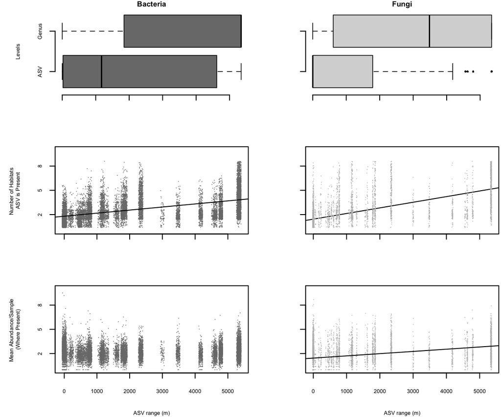

```r
#####################
#Plot Fungi: # of Habitats vs. ASV Range (PLOT 4, row 2)
# fung_habrange
plot(jitter(rangespanF,20),jitter(habitatsF,3), yaxt="n", xaxt="n", ylim=c(0,10), pch=16,
    col="gray74", cex=0.2, xlab="",  cex.axis=0.6, ylab="",
    abline(lsfit(rangespanF,habitatsF), col="black", lwd=1))
    axis(side=1,labels=F, tck=-0.06)
    axis(side=2,labels=F, tck=-0.06, at=seq(2,10, by=3))


#Calculate correlation
cor.test(rangespanF, habitatsF)
#text(temp, expression(paste( italic("R^2 = 0.451
#   p < 0.001"))))

#####################
# Plot Bacteria: Mean Abundance vs. ASV Range (PLOT 5,  row 3)
plot(jitter(rangespan,20),jitter(log(meanabund),3),col="gray48", cex=0.2, pch=16,
     xaxt="n", yaxt="n", ylim=c(0,10),
     cex.lab=0.6, xlab="ASV range (m)", ylab="Mean Abundance/Sample \n(Where Present)") +
axis(side=1,labels=T, tck=-0.06, cex.axis=0.6)
axis(side=2,labels=T, tck=-0.06, cex.axis=0.6, at=seq(2,10, by=3))

#Calculate correlation
cor.test(rangespan, meanabund)
#text(temp,expression(paste( italic("R^2 < 0.001
#   p = 0.554"))))

#####################
# Plot Fungi: Mean abundance vs. ASV Range (PLOT 6, row 3)
plot(jitter(rangespanF,20),jitter(log(meanabundF),3),col="gray74", cex=0.2, xaxt="n", ylim=c(0,10),
     yaxt="n", cex.lab=0.6, xlab="ASV range (m)", ylab="", pch=16) +
  abline(lsfit(rangespanF,log(meanabundF)), col="black", lwd=1)
axis(side=1,labels=T, tck=-0.06, cex.axis=0.6)
axis(side=2,labels=F, tck=-0.06, at=seq(2,10, by=3))
```

```r
#Calculate correlation
cor.test(rangespanF, meanabundF)
#text(temp,expression(paste( italic("R^2 = 0.012
#   p < 0.001"))))


dev.print(png, "figures/ASV.range.png", units="in", width=6, height=5, res=300)
dev.off()
```

Additional taxonomy summary for abundance-occupancy data, used in Supplementary Figures 4 and 5

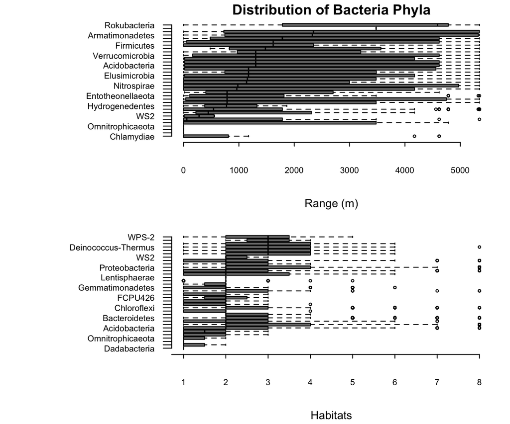

```r
### TaxonomySummary ####
bacttax=tax_table(binarysite)
bactaxrange=data.frame(bacttax,rangespan,habitats)
#head(bactaxrange)

bacphybymedrange <- with(bactaxrange, reorder(Phylum, rangespan, median))
bacphybymedhab <- with(bactaxrange, reorder(Phylum, habitats, median))

### Bacteria phyla plot
par(mfrow=c(2,1), mar=c(4,10,1,1)+0.1)

# Bacteria rangespan
boxplot(bactaxrange$rangespan~bacphybymedrange, las=2, horizontal=TRUE, frame=F, cex.main=1,
        main="Distribution of Bacteria Phyla", col="gray48", cex=0.4, medlwd=1.5,
        xaxt="n", tck=-0.03, xlab="Range (m)", ylab="", cex.axis=0.6, cex.lab=0.8)
axis(side=1, labels=T, seq(0,5500, by=1000), cex.axis=0.6, cex.lab=0.6, tck=-0.03)


# Bacteria habitats
boxplot(bactaxrange$habitats~bacphybymedhab, las=2, horizontal=TRUE, frame=F, xaxt="n", tck=-0.03,
        col="gray48", xlab="Habitats", cex.axis=0.6, cex.lab=0.8, ylab="", cex=0.4, medlwd=1.5)
axis(side=1, labels=T, seq(0,8, by=1), cex.axis=0.6, cex.lab=0.6, tck=-0.03)
```

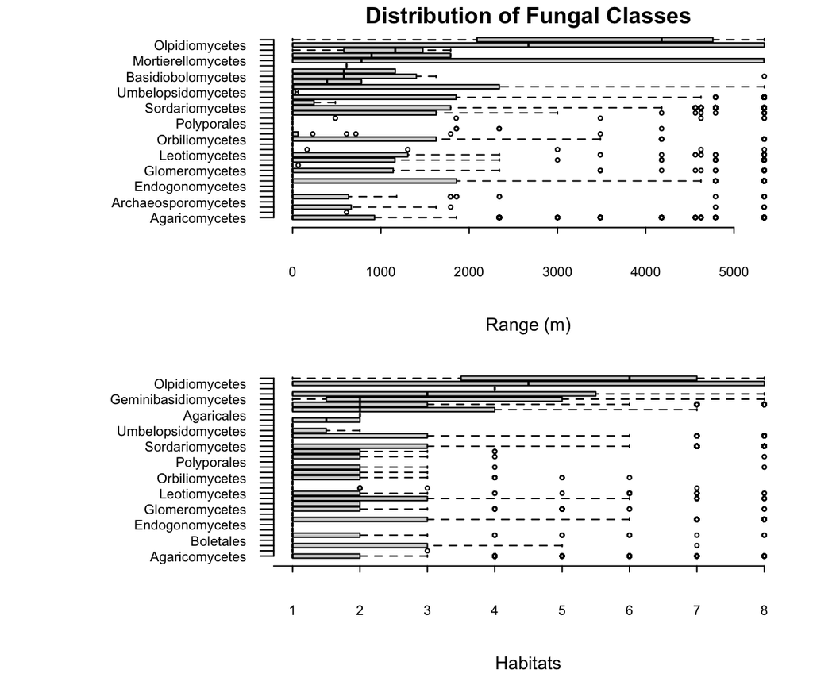

```r
dev.copy(png, "figures/BactTax.range.hab.png", units="in", width=6, height=7, res=300)
dev.off()


######### Fungi
funtax=tax_table(binarysiteF)
funtaxrange=data.frame(funtax,rangespanF,habitatsF)
#head(funtaxrange)

funphybymedrange <- with(funtaxrange, reorder(Class, rangespanF, median))
funphybymedhab <- with(funtaxrange, reorder(Class, habitatsF, median))

### Fungi class plot
par(mfrow=c(2,1), mar=c(4,10,1,1)+0.1)

# Fungi rangespan
boxplot(funtaxrange$rangespanF~funphybymedrange,las=2, horizontal=TRUE, frame=F, cex.main=1,
        main="Distribution of Fungal Classes", col="gray84", cex=0.4, medlwd=1.5,
        xaxt="n", tck=-0.03, xlab="Range (m)", ylab="", cex.axis=0.6, cex.lab=0.8)
axis(side=1, labels=T, seq(0,5500, by=1000), cex.axis=0.6, cex.lab=0.6, tck=-0.03)

# Fungi habitats
boxplot(funtaxrange$habitatsF~funphybymedhab, las=2, horizontal=TRUE, frame=F, xaxt="n", tck=-0.03,
        col="gray84", xlab="Habitats", cex.axis=0.6, cex.lab=0.8, ylab="", cex=0.4, medlwd=1.5)
axis(side=1, labels=T, seq(0,8, by=1), cex.axis=0.6, cex.lab=0.6, tck=-0.03)
```

```r
dev.copy(png, "figures/FungTax.range.hab.png", units="in", width=6, height=7, res=300)
dev.off()
```

#### Rangespan of microbiome communities

Now create a plot for rangespan–the range in meters for each ASV–and the frequency of phytobiomes for bacteria and fungi.

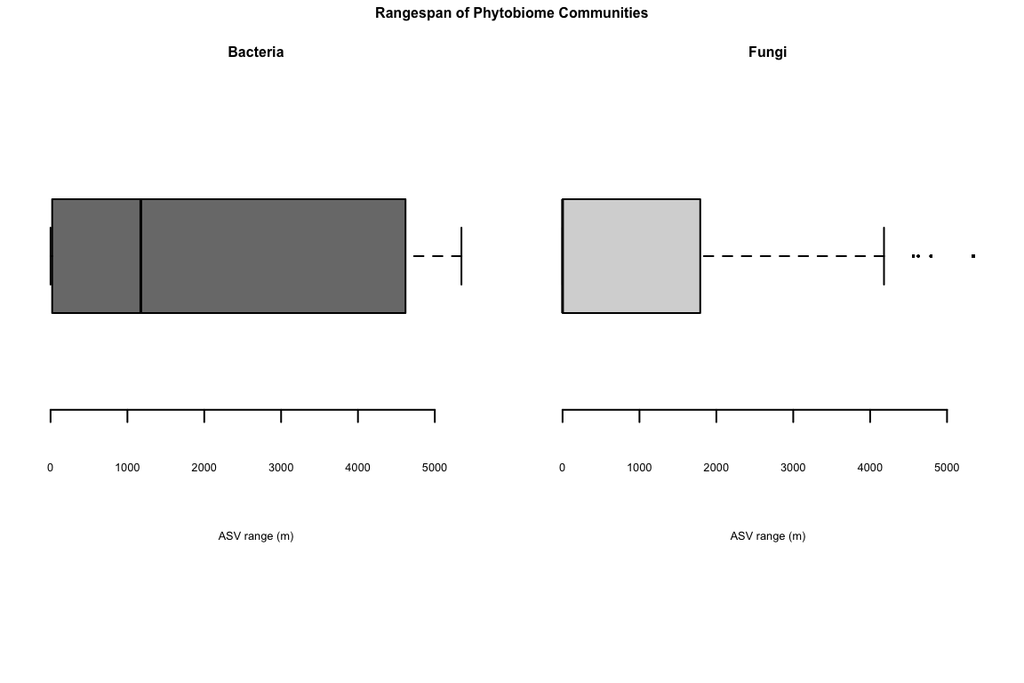

```r
##FIGURE 2. RANGESPAN OF PHYTOBIOME COMMUNITIES
#Set layout to combine boxplot and histogram
#Next plots will be created next to each other
par(mfrow=c(1,2), mar=c(8,1,3,1))

#First plot: Bacterial rangespan
boxplot(rangespan, horizontal=TRUE, vertical=TRUE, col="gray48", main="Bacteria", frame=F, cex=0.5, cex.lab=0.4, xlab="ASV range (m)", cex.main=0.5, xaxt="n", medlwd=1.5)
axis(side=1, labels=T, seq(0,5000, by=1000), cex.axis=0.4, tck=-0.04)

#Second Plot: Fungal rangespan
boxplot(rangespanF, horizontal=TRUE  , col="gray84", main="Fungi", frame=F, cex.main=0.5, xlab="ASV range (m)", xaxt="n", cex=0.2, cex.lab=0.4, medlwd=1.5, pch=16)
axis(side=1, labels=T, seq(0,5000, by=1000), cex.axis=0.4, tck=-0.04)

#Add title to figure!
title(main = "Rangespan of Phytobiome Communities", outer = TRUE, line = -0.5, cex.main=0.5)
```

```r
dev.copy(png, "figures/community.rangespan.png", units="in", width=4, height=3, res=300)
dev.off()
```

#### Nestedness plots

What is the nestedness for each community within the microhabitats of plant-parts and do they relate to each other among habitats (the sites of collection)?

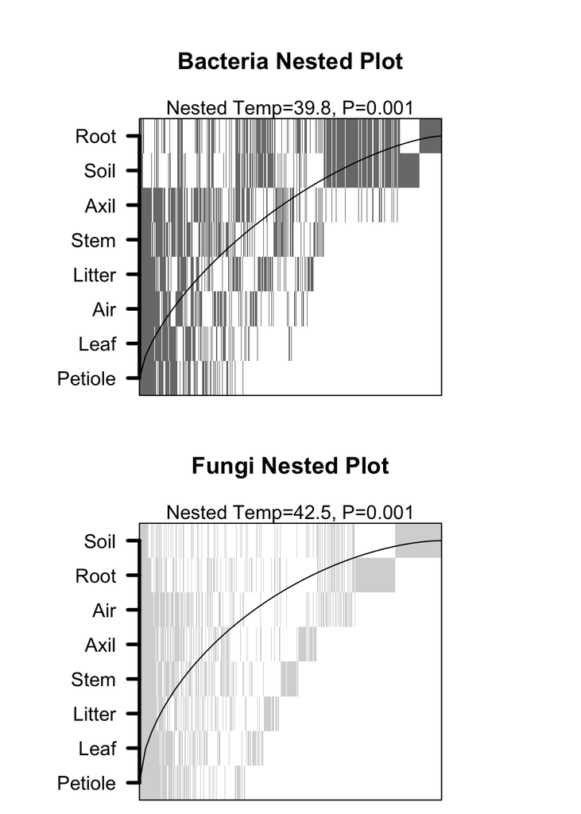

```r
#Code by Anthony
#To produce nestedness plots

#read in rarefied Bacteria data
rarPhySeq=readRDS("data/rarPhySeq.gz")
rarPhySeq<- subset_taxa(rarPhySeq, c(Kingdom != "unknown", Kingdom != "Eukaryota"))

#Merge samples by sample type
agg=merge_samples(rarPhySeq, "SampleType")

#convert to dataframe
aggtab=as.data.frame(otu_table(agg))

#calculate nested temperature
nested=nestedtemp(aggtab)

#read in Fungal data (not rarefied)
fungalphyseq1=readRDS("data/fungal_physeq1.gz")

#rarefy to 20000 sequences (drops 3 samples :())
funrarPhySeq=rarefy_even_depth(fungalphyseq1, sample.size=20000)

#merge by sample type
funagg=merge_samples(funrarPhySeq, "SampleType")

#convert to dataframe
funaggtab=as.data.frame(otu_table(funagg))

#calculate nested temp
funnested=nestedtemp(funaggtab)

#make a two row composite figure, reguce spacing between inner and outer margins
par(mfrow=c(2,1), mai=c(.1,1.,1,1), oma=c(.1,1,.1,1))
#plot the Bacteria nested figure, suppress taxon names
plot(nested, kind="incid", names=c(TRUE,FALSE), col=c("white", "gray48"), lwd=3, main="Bacteria Nested Plot")
#add stats are margin text
mtext("Nested Temp=39.8, P=0.001")
#plot the fungal nested figure, suppress taxon names
plot(funnested, kind="incid", names=c(TRUE,FALSE), col=c("white", "gray84"), lwd=3, main="Fungi Nested Plot")
#add stats as margin text
mtext("Nested Temp=42.5, P=0.001")
```

```r
dev.print(png, "figures/nestedplots.png", units="in", width=6, height=6, res=300)
```

```r
dev.off()
```

#### Mantel Tests

Tests here show the relationships between plant parts (or plant organs) and bacterial communities fungal communities across geographic distance. The **exported table** uses Hellinger square-root trasnformed abundance data in Mantel tests with p-values and Bonferroni corrected p-values.

```r
## Mantel Tests and Slope Plots By Plant Part
## Chad Wilhite 04/25/19
## edited Chris Wall

####################################
#### Mantel Tests by SampleType ####
####################################

#
##
###
#### Bacteria Analysis

# Load RDS file of normalized bacterial reads
PS_normal = readRDS("data/PS_normal.gz") #"PS_normal"
PS_normal<- subset_taxa(PS_normal, c(Kingdom != "unknown", Kingdom != "Eukaryota"))

# Hellinger (square root) transform the data!
PS_normal.hell = transform_sample_counts(PS_normal, function(x) x^0.5)

# View SampleType names
# unique(get_variable(PS_normal.hell, sample_variables(PS_normal.hell)[18]))

### Subset out bacterial data by SampleType

# Subset bacterial data by plant part - the hard way... xD
stem_otu = subset_samples(PS_normal.hell, SampleType=="Stem")
root_otu = subset_samples(PS_normal.hell, SampleType=="Root")
air_otu  = subset_samples(PS_normal.hell, SampleType=="Air")
leaf_otu = subset_samples(PS_normal.hell, SampleType=="Leaf")
soil_otu = subset_samples(PS_normal.hell, SampleType=="Soil")
litt_otu = subset_samples(PS_normal.hell, SampleType=="Litter")
axil_otu = subset_samples(PS_normal.hell, SampleType=="Axil")
peti_otu = subset_samples(PS_normal.hell, SampleType=="Petiole")


### Generate Dissimilarity Matrices for bacterial OTU data

# Generate a dissimilarity matrix for grouped and individual plant part bacterial OTU data
# adding "phyloseq::" to specify to run this through phyloseq and not other packages.

all_otu.dist  = phyloseq::distance(PS_normal.hell, "bray")
stem_otu.dist = phyloseq::distance(stem_otu, "bray")
root_otu.dist = phyloseq::distance(root_otu, "bray")
air_otu.dist  = phyloseq::distance(air_otu,  "bray")
leaf_otu.dist = phyloseq::distance(leaf_otu, "bray")
soil_otu.dist = phyloseq::distance(soil_otu, "bray")
litt_otu.dist = phyloseq::distance(litt_otu, "bray")
axil_otu.dist = phyloseq::distance(axil_otu, "bray")
peti_otu.dist = phyloseq::distance(peti_otu, "bray")


### Create correctly ordered sized geographic distance dissimilarity matrix

#Gather bacterial spatial data from the phyloseq object
all.geo  = cbind(sample_data(PS_normal.hell)$Lon, sample_data(PS_normal.hell)$Lat)
stem.geo = cbind(sample_data(stem_otu)$Lon, sample_data(stem_otu)$Lat)
root.geo = cbind(sample_data(root_otu)$Lon, sample_data(root_otu)$Lat)
air.geo  = cbind(sample_data(air_otu)$Lon,  sample_data(air_otu)$Lat)
leaf.geo = cbind(sample_data(leaf_otu)$Lon, sample_data(leaf_otu)$Lat)
soil.geo = cbind(sample_data(soil_otu)$Lon, sample_data(soil_otu)$Lat)
litt.geo = cbind(sample_data(litt_otu)$Lon, sample_data(litt_otu)$Lat)
axil.geo = cbind(sample_data(axil_otu)$Lon, sample_data(axil_otu)$Lat)
peti.geo = cbind(sample_data(peti_otu)$Lon, sample_data(peti_otu)$Lat)

# Generate a dissimilarity matrix for grouped (all plant parts) and by plant part
#   bacterial geographic distance data
all.geodist  = earth.dist(all.geo)
stem.geodist = earth.dist(stem.geo)
root.geodist = earth.dist(root.geo)
air.geodist  = earth.dist(air.geo)
leaf.geodist = earth.dist(leaf.geo)
soil.geodist = earth.dist(soil.geo)
litt.geodist = earth.dist(litt.geo)
axil.geodist = earth.dist(axil.geo)
peti.geodist = earth.dist(peti.geo)

#Mantel test by SampleType
all_bacteria_mantel  = mantel(log( all.geodist+1),log( all_otu.dist), permutations= 999)
stem_bacteria_mantel = mantel(log(stem.geodist+1),log(stem_otu.dist), permutations= 999)
root_bacteria_mantel = mantel(log(root.geodist+1),log(root_otu.dist), permutations= 999)
air_bacteria_mantel  = mantel(log( air.geodist+1),log( air_otu.dist), permutations= 999)
leaf_bacteria_mantel = mantel(log(leaf.geodist+1),log(leaf_otu.dist), permutations= 999)
soil_bacteria_mantel = mantel(log(soil.geodist+1),log(soil_otu.dist), permutations= 999)
litt_bacteria_mantel = mantel(log(litt.geodist+1),log(litt_otu.dist), permutations= 999)
axil_bacteria_mantel = mantel(log(axil.geodist+1),log(axil_otu.dist), permutations= 999)
peti_bacteria_mantel = mantel(log(peti.geodist+1),log(peti_otu.dist), permutations= 999)



#############################################
################ Fungal #####################
#############################################

#Load RDS file of fungal reads
FPS_normal = readRDS("data/fungal_PS_normal.gz") #"fungal_PS_normal"

#square root transform (Hellinger)
FPS_normal.hell = transform_sample_counts(FPS_normal, function(x) x^0.5)

#Subset Fungal Data by SampleType
fstem_otu = subset_samples(FPS_normal.hell, SampleType=="Stem")
froot_otu = subset_samples(FPS_normal.hell, SampleType=="Root")
fair_otu  = subset_samples(FPS_normal.hell, SampleType=="Air")
fleaf_otu = subset_samples(FPS_normal.hell, SampleType=="Leaf")
fsoil_otu = subset_samples(FPS_normal.hell, SampleType=="Soil")
flitt_otu = subset_samples(FPS_normal.hell, SampleType=="Litter")
faxil_otu = subset_samples(FPS_normal.hell, SampleType=="Axil")
fpeti_otu = subset_samples(FPS_normal.hell, SampleType=="Petiole")


#Generate Distance Matrix
fall_otu.dist  = phyloseq::distance(FPS_normal.hell, "bray")
fstem_otu.dist = phyloseq::distance(fstem_otu, "bray")
froot_otu.dist = phyloseq::distance(froot_otu, "bray")
fair_otu.dist  = phyloseq::distance( fair_otu, "bray")
fleaf_otu.dist = phyloseq::distance(fleaf_otu, "bray")
fsoil_otu.dist = phyloseq::distance(fsoil_otu, "bray")
flitt_otu.dist = phyloseq::distance(flitt_otu, "bray")
faxil_otu.dist = phyloseq::distance(faxil_otu, "bray")
fpeti_otu.dist = phyloseq::distance(fpeti_otu, "bray")


#Gather fungal spatial data from the phyloseq object
fall.geo  = cbind(sample_data(FPS_normal.hell)$Lon, sample_data(FPS_normal.hell)$Lat)
fstem.geo = cbind(sample_data(fstem_otu)$Lon, sample_data(fstem_otu)$Lat)
froot.geo = cbind(sample_data(froot_otu)$Lon, sample_data(froot_otu)$Lat)
fair.geo  = cbind(sample_data( fair_otu)$Lon, sample_data( fair_otu)$Lat)
fleaf.geo = cbind(sample_data(fleaf_otu)$Lon, sample_data(fleaf_otu)$Lat)
fsoil.geo = cbind(sample_data(fsoil_otu)$Lon, sample_data(fsoil_otu)$Lat)
flitt.geo = cbind(sample_data(flitt_otu)$Lon, sample_data(flitt_otu)$Lat)
faxil.geo = cbind(sample_data(faxil_otu)$Lon, sample_data(faxil_otu)$Lat)
fpeti.geo = cbind(sample_data(fpeti_otu)$Lon, sample_data(fpeti_otu)$Lat)


#Create correct sized fungal geographic distance dissimilarity matrix
fall.geodist  = earth.dist( fall.geo)
fstem.geodist = earth.dist(fstem.geo)
froot.geodist = earth.dist(froot.geo)
fair.geodist  = earth.dist( fair.geo)
fleaf.geodist = earth.dist(fleaf.geo)
fsoil.geodist = earth.dist(fsoil.geo)
flitt.geodist = earth.dist(flitt.geo)
faxil.geodist = earth.dist(faxil.geo)
fpeti.geodist = earth.dist(fpeti.geo)


#Mantel test by SampleType
fall_mantel  = mantel(log( fall.geodist+1),log( fall_otu.dist), permutations= 999)
fstem_mantel = mantel(log(fstem.geodist+1),log(fstem_otu.dist), permutations= 999)
froot_mantel = mantel(log(froot.geodist+1),log(froot_otu.dist), permutations= 999)
fair_mantel  = mantel(log( fair.geodist+1),log( fair_otu.dist), permutations= 999)
fleaf_mantel = mantel(log(fleaf.geodist+1),log(fleaf_otu.dist), permutations= 999)
fsoil_mantel = mantel(log(fsoil.geodist+1),log(fsoil_otu.dist), permutations= 999)
flitt_mantel = mantel(log(flitt.geodist+1),log(flitt_otu.dist), permutations= 999)
faxil_mantel = mantel(log(faxil.geodist+1),log(faxil_otu.dist), permutations= 999)
fpeti_mantel = mantel(log(fpeti.geodist+1),log(fpeti_otu.dist), permutations= 999)


###################################################
# Save Mantel Correlation Statistics and P Values #
###################################################

#Call plant part results
mant_cor = as.data.frame(c(stem_bacteria_mantel$statistic, root_bacteria_mantel$statistic,
    air_bacteria_mantel$statistic, leaf_bacteria_mantel$statistic,
    soil_bacteria_mantel$statistic, litt_bacteria_mantel$statistic,
    axil_bacteria_mantel$statistic, peti_bacteria_mantel$statistic,
    fstem_mantel$statistic, froot_mantel$statistic, fair_mantel$statistic,
    fleaf_mantel$statistic, fsoil_mantel$statistic, flitt_mantel$statistic,
    faxil_mantel$statistic, fpeti_mantel$statistic))

#Call plant part p-values
p_val = c(stem_bacteria_mantel$signif, root_bacteria_mantel$signif,
    air_bacteria_mantel$signif, leaf_bacteria_mantel$signif,
    soil_bacteria_mantel$signif, litt_bacteria_mantel$signif,
    axil_bacteria_mantel$signif, peti_bacteria_mantel$signif,
    fstem_mantel$signif, froot_mantel$signif, fair_mantel$signif,
    fleaf_mantel$signif, fsoil_mantel$signif, flitt_mantel$signif,
    faxil_mantel$signif, fpeti_mantel$signif)

#Create results data frame with mantel R and p-values for each plant part
results = data.frame( c( rep('Bacterial',8), rep('Fungal',8) ),
    c( rep( c('Stem', 'Root', 'Air', 'Leaf', 'Soil', 'Litter', 'Axil', 'Petiole'),2 ) ),
    mant_cor, p_val
    )

#Name the columns intelligible names
colnames(results) = c('Type', 'Part', 'Mant_cor', 'p_val')

#Adjust p-values for repeated tests on the within plant part groups for bacteria
bact.cor.p = p.adjust(results[results$Type == 'Bacterial',4], method = 'bonferroni')
bact.cor.p = data.frame(cor.p = bact.cor.p, Type = rep('Bacterial',8),
    Part = as.character(unique(results$Part)) )

#Adjust p-values for repeated tests on the within plant part groups for fungi
fung.cor.p = p.adjust(results[results$Type == 'Fungal',4], method = 'bonferroni')
fung.cor.p = data.frame(cor.p = fung.cor.p, Type = rep('Fungal',8),
    Part = as.character(unique(results$Part)) )

#Join corrected p-values to for fungus and bacteria together
cor.p = rbind(bact.cor.p, fung.cor.p)


#Join corrected p-values to results data frame
results = merge(results, cor.p)


#Add overall test (all parts together) to data frame
results2 = rbind(results, data.frame(Type = c('Bacterial', 'Fungal'), Part = rep('All',2),
    Mant_cor = c(all_bacteria_mantel$statistic, fall_mantel$statistic),
    p_val = c(all_bacteria_mantel$signif, fall_mantel$signif),
    cor.p = rep('NA', 2))
    )

#Save all result data as a csv
write.csv(results2, file = 'output/Mantel_Plant_Part_Results_Hell_Bray.csv')
knitr::kable(results2, digits = c(0, 0, 3, 3, 3, 3))
```

| Type | Part | Mant_cor | p_val | cor.p |
| --- | --- | --- | --- | --- |
| Bacterial | Air | 0.174 | 0.284 | 1 |
| Bacterial | Axil | 0.075 | 0.327 | 1 |
| Bacterial | Leaf | 0.213 | 0.140 | 1 |
| Bacterial | Litter | 0.280 | 0.131 | 1 |
| Bacterial | Petiole | 0.187 | 0.216 | 1 |
| Bacterial | Root | 0.444 | 0.001 | 0.008 |
| Bacterial | Soil | 0.044 | 0.392 | 1 |
| Bacterial | Stem | 0.245 | 0.188 | 1 |
| Fungal | Air | 0.613 | 0.001 | 0.008 |
| Fungal | Axil | 0.225 | 0.186 | 1 |
| Fungal | Leaf | 0.114 | 0.226 | 1 |
| Fungal | Litter | 0.598 | 0.002 | 0.016 |
| Fungal | Petiole | 0.670 | 0.002 | 0.016 |
| Fungal | Root | 0.700 | 0.001 | 0.008 |
| Fungal | Soil | 0.674 | 0.008 | 0.064 |
| Fungal | Stem | 0.555 | 0.003 | 0.024 |
| Bacterial | All | 0.116 | 0.001 | NA |
| Fungal | All | 0.364 | 0.001 | NA |

### PERMANOVA

```r
##PERMANOVA Bacteria
PS_normal = readRDS("data/PS_normal.gz")
PS_normal=transform_sample_counts(PS_normal, function(x) x^0.5)

PS_normal = subset_taxa(PS_normal, c(
                          Order!="Chloroplast",
                          Kingdom!="Archaea",
                          Family!="Mitochondria",
                          Kingdom!="Unknown",
                          Kingdom!="Eukaryota"))


#Use base boxplot functin to look at sequencing depth
#boxplot(sample_sums(PS_normal)~sample_data(PS_normal)$FieldSite)
#boxplot(sample_sums(PS_normal)~sample_data(PS_normal)$SampleType)

#Bacterial ALL
Site <- as.factor(PS_normal@sam_data$FieldSite)
Sample_Type <- PS_normal@sam_data$SampleType
bact_ps <- phyloseq::distance(PS_normal, method="bray") #Normalized bact data - phyloseq-class
bact_meta_all = as(sample_data(PS_normal), "data.frame") #Extract sample data and coerce to df
bact_all = adonis(bact_ps ~ Site + Sample_Type, by = "margin", data = bact_meta_all, permutations = 10000)
bact_all
```

```
##
## Call:
## adonis(formula = bact_ps ~ Site + Sample_Type, data = bact_meta_all,      permutations = 10000, by = "margin")
##
## Permutation: free
## Number of permutations: 10000
##
## Terms added sequentially (first to last)
##
##             Df SumsOfSqs MeanSqs F.Model      R2    Pr(>F)
## Site         8    4.0127 0.50159  2.0569 0.15102 9.999e-05 ***
## Sample_Type  7    8.9018 1.27169  5.2150 0.33503 9.999e-05 ***
## Residuals   56   13.6557 0.24385         0.51395
## Total       71   26.5702                 1.00000
## ---
## Signif. codes:  0 '***' 0.001 '**' 0.01 '*' 0.05 '.' 0.1 ' ' 1
```

```r
##PERMANOVA Fungi
FPS_normal = readRDS("data/fungal_PS_normal.gz")

fun_ps = transform_sample_counts(FPS_normal, function(x) x^0.5)
site <- as.factor(FPS_normal@sam_data$FieldSite)
SampleType <- FPS_normal@sam_data$SampleType
fun_ps <- phyloseq::distance(fun_ps, method="bray") #Normalized bact data - phyloseq-class
fun_meta_all = as(sample_data(FPS_normal), "data.frame") # Extract sample data and coerce to df
fun_all = adonis(fun_ps ~ site + SampleType, by = "margin", data = fun_meta_all, permutations = 10000)
fun_all
```

```
##
## Call:
## adonis(formula = fun_ps ~ site + SampleType, data = fun_meta_all,      permutations = 10000, by = "margin")
##
## Permutation: free
## Number of permutations: 10000
##
## Terms added sequentially (first to last)
##
##            Df SumsOfSqs MeanSqs F.Model      R2    Pr(>F)
## site        8    6.5486 0.81858  3.2380 0.25541 9.999e-05 ***
## SampleType  7    4.9343 0.70491  2.7884 0.19245 9.999e-05 ***
## Residuals  56   14.1570 0.25280         0.55215
## Total      71   25.6399                 1.00000
## ---
## Signif. codes:  0 '***' 0.001 '**' 0.01 '*' 0.05 '.' 0.1 ' ' 1
```

#### NMDS

Non-metric multidimensional scaling (NMDS) using Bray-Curtis ordination for Hellinger transformed bacterial and fungal communities with elipses and points for each plant-part.

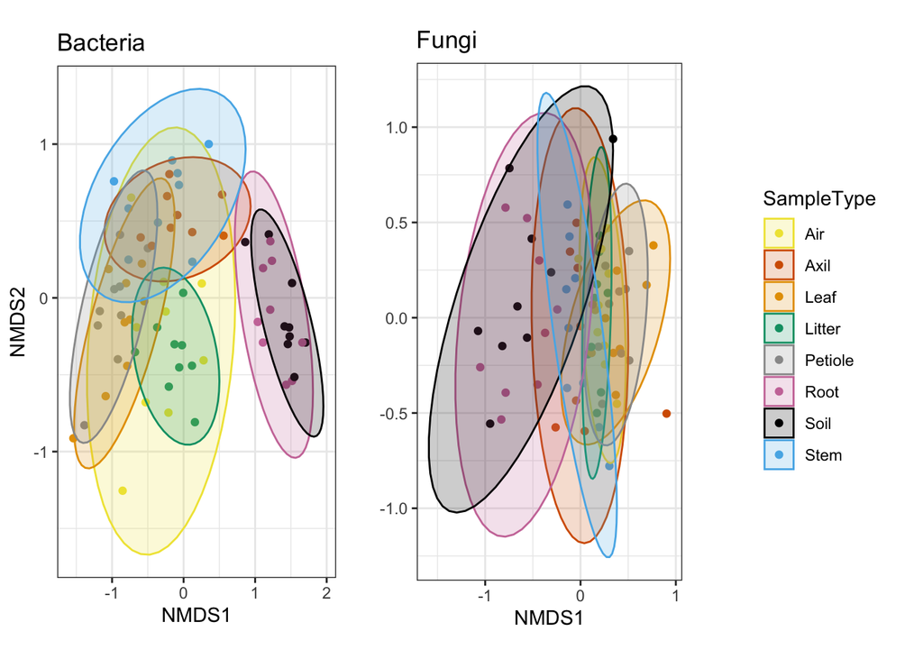

```r
#Code by Maria and Helen
#For NMDS plots and heat maps by Sample Type

#read in normalized bacterial data
PS_normal<-readRDS("data/PS_normal.gz")
PS_normal<- subset_taxa(PS_normal, c(Kingdom != "unknown", Kingdom != "Eukaryota"))

#read in bacteria phyloseq data
physeq1 <- readRDS("data/physeq1.gz")
physeq1<- subset_taxa(physeq1, c(Kingdom != "unknown", Kingdom != "Eukaryota"))

#read in rarified phyloseq data
rarPhySeq <- readRDS("data/rarPhySeq.gz")
rarPhySeq<- subset_taxa(rarPhySeq, c(Kingdom != "unknown", Kingdom != "Eukaryota"))

#read in normalized fungal taxa
fungal_norm<-readRDS("data/fungal_PS_normal.gz")

#read in fungal phyloseq data
funphys <- readRDS("data/fungal_physeq1.gz")

#read in rarified phyloseq data
rarfun <- readRDS("data/fungal_rarPhySeq.gz")

####################################
##########NMDS PLOTS##############
#hellinger transform bacteria
phyobj.hell=transform_sample_counts(PS_normal, function(x) x^0.5)

#hellinger transform fungus
fungal.hell<-transform_sample_counts(fungal_norm,  function(x) x^0.5)

##Organize sample type by levels of ground to air in all datasets
sample_data(PS_normal)$SampleType = factor(sample_data(PS_normal)$SampleType, levels = c('Soil', 'Root', 'Stem', 'Axil', 'Petiole', 'Leaf','Litter','Air'))

sample_data(physeq1)$SampleType = factor(sample_data(physeq1)$SampleType, levels = c('Soil', 'Root', 'Stem', 'Axil', 'Petiole', 'Leaf','Litter','Air'))

sample_data(rarPhySeq)$SampleType = factor(sample_data(rarPhySeq)$SampleType, levels = c('Soil', 'Root', 'Stem', 'Axil', 'Petiole', 'Leaf','Litter','Air'))

##Organize sample type by levels of ground to air in all datasets for fungus
sample_data(fungal_norm)$SampleType = factor(sample_data(fungal_norm)$SampleType, levels = c('Soil', 'Root', 'Stem', 'Axil', 'Petiole', 'Leaf','Litter','Air'))

sample_data(funphys)$SampleType = factor(sample_data(funphys)$SampleType, levels = c('Soil', 'Root', 'Stem', 'Axil', 'Petiole', 'Leaf','Litter','Air'))

sample_data(rarfun)$SampleType = factor(sample_data(rarfun)$SampleType, levels = c('Soil', 'Root', 'Stem', 'Axil', 'Petiole', 'Leaf','Litter','Air'))

#bacteria ordination
phyobj.ord<-ordinate(phyobj.hell, "NMDS", "bray")

#fungus ordination
funhell.ord<-ordinate(fungal.hell, "NMDS", "bray")

#define colorblind friendly color palette
cbPalette1<- c("#F0E442","#D55E00","#E69F00","#009E73","#999999","#CC79A7","#000000","#56B4E9","#0072B2")

#bacteria NMDS by sample type
bac.NMDS<-plot_ordination(phyobj.hell, phyobj.ord, type="samples", color="SampleType", title="Bacteria") +
  theme(legend.position="none") +
  scale_fill_manual(values=cbPalette1) +
  scale_colour_manual(values=cbPalette1)+
  stat_ellipse(geom="polygon",type="t", alpha=0.2, aes(fill=SampleType)) +
  theme(legend.position="none") + coord_equal(ratio=2.15) +
  theme_bw()


#fungal NMDS by sample type
fung.NMDS<-plot_ordination(fungal.hell, funhell.ord,type="samples", color="SampleType", title="Fungi") +
  scale_fill_manual(values=cbPalette1) +
  scale_colour_manual(values=cbPalette1)+
  ylab("")+
  stat_ellipse(geom="polygon", type="t", alpha=0.2, aes(fill=SampleType)) +
  theme(legend.position="none") +  coord_equal(ratio=2) +
  theme_bw()

NMDS.legend <- get_legend(
    # create some space to the left of the legend
    fung.NMDS + theme(legend.box.margin = margin(0, 0, 0, 12)))

NMDS.plots<- plot_grid(bac.NMDS + theme(legend.position = "none"),
                     fung.NMDS + theme(legend.position = "none"),
                     ncol=2,nrow=1)

plot_grid(NMDS.plots, NMDS.legend, rel_widths = c(3, 1)) # legend  1/3 size as first obj.
```

```r
dev.copy(pdf, "figures/NMDS.fig.pdf", width = 6, height = 4)
```

#### Heatmaps

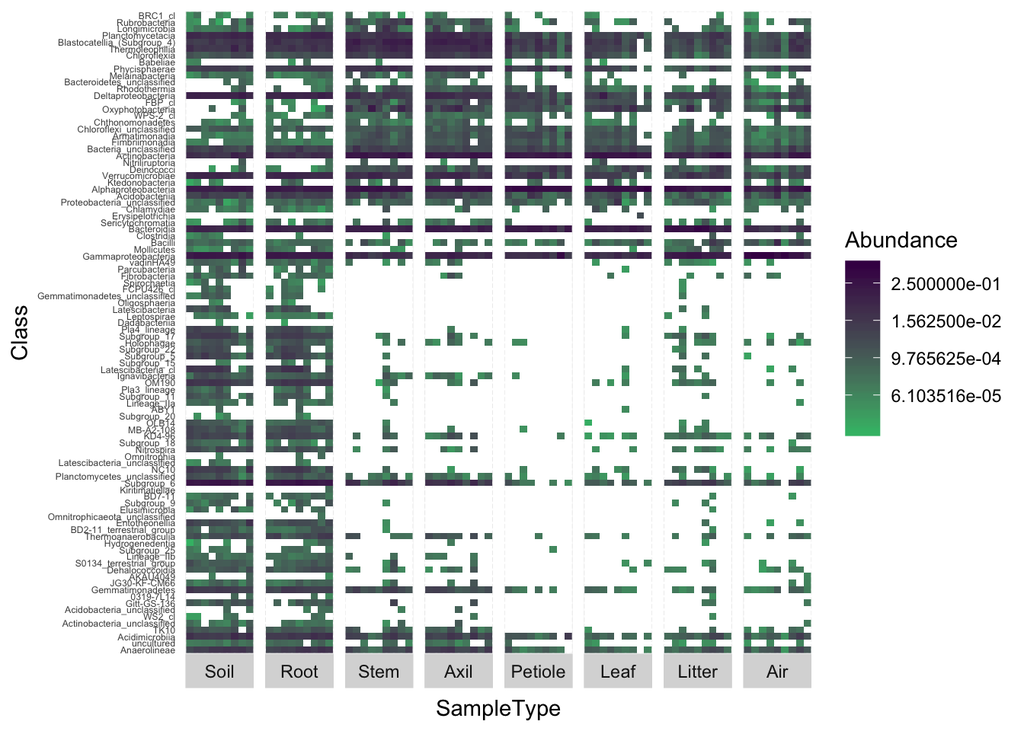

```r
####HEAT MAP DATA####

##Helen Sung, edited by Jared Bernard

###Load phyloseq files###
bacteria <- readRDS("data/PS_normal.gz") ## normalized phyloseq data
bacteria <- subset_taxa(bacteria, Kingdom != "unknown") #Remove unclassified kingdoms
bacteria <- subset_taxa(bacteria, Kingdom != "Eukaryota")   #Remove eukaryotes
bacteria <- subset_taxa(bacteria, Kingdom=="Bacteria")

fungi <- readRDS("data/fungal_PS_normal.gz") ## normalized phyloseq data
fungi <- subset_taxa(fungi, Kingdom=="Fungi")

###Fix Data to properly format for Heatmaps###
##Substitute all of the FieldSite 10 into 9 in all datasets
gsub("10", "9", (sample_data(bacteria)$FieldSite))
gsub("10", "9", (sample_data(fungi)$FieldSite))

##Replace old fieldsite names with new fieldsite names in all datasets
sample_data(bacteria)$FieldSite
sample_data(fungi)$FieldSite

##Organize sample type by levels of ground to air in all datasets
sample_data(bacteria)$SampleType = factor(sample_data(bacteria)$SampleType, levels = c('Soil', 'Root', 'Stem', 'Axil', 'Petiole', 'Leaf','Litter','Air'))
sample_data(fungi)$SampleType = factor(sample_data(fungi)$SampleType, levels = c('Soil', 'Root', 'Stem', 'Axil', 'Petiole', 'Leaf','Litter','Air'))

###Subset Data###
# NOTE: Can put any physeq dataset (i.e. PS_normal, physeq1, rarPhySeq, phyobject.hell) into tax_glom(physeqobject, taxrank = "Rank you want to subset to") to subset
# tax_glom() gloms things together at the specified rank and it will get rid of anything that's not classified at that level

##Pool all ASVs by Class
class_dat <- tax_glom(bacteria, taxrank="Class") ## subsetting for normalized data
funclass <- tax_glom(fungi, taxrank="Class")

###Plot Heatmap###
# NOTE: Can put any Subsetted physeq dataset (i.e. phy_dat, ord_dat, etc.) or non-subsetted physeq dataset (i.e. physeq1, PS_normal, etc.) into plot_heatmap(physeqobject, ...)
# NOTE: If using a subsetted physeq dataset, make sure set the taxa.label = taxrank for whichever taxonomic rank you make heatmap for

#Plot bacterial heatmap clustering by NMDS and Bray curtis distance, labeling sample type and supressing Taxon labels
b1 <- plot_heatmap(class_dat, "NMDS", "bray", sample.label = "SampleType", sample.order= "FieldSite", taxa.label="Class", low = "#3CBB75FF", high = "#440154FF", na.value= "white")
#Organize by field sites and grouped by sample type
d1 <- b1+ facet_grid(~SampleType, scales= "free_x", switch = "x")
#Plot Heatmap with tick marks and FieldSite labels removed
d2 <- d1 + theme(
  axis.text.x = element_blank(),
  axis.ticks = element_blank()
  )
plot(d2)
```

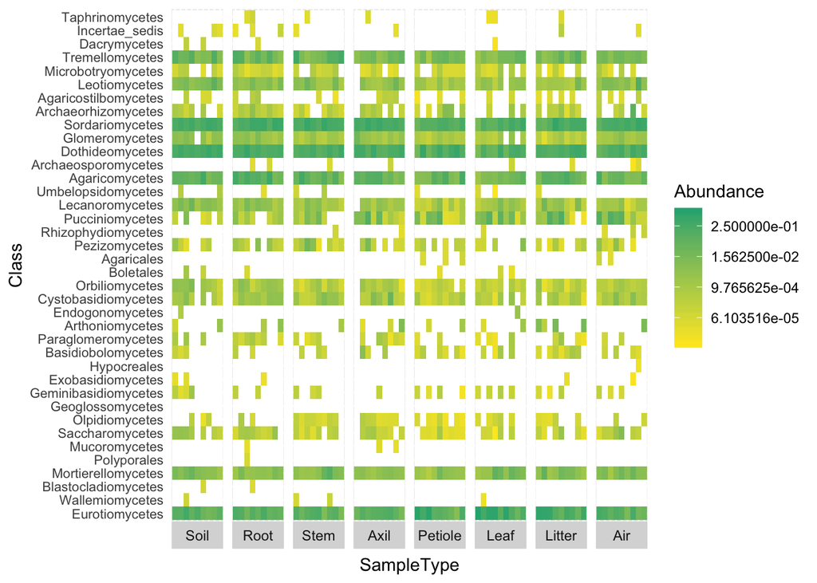

```r
##Save Heatmap as tiff file
tiff("figures/16s_class_heatmap_PSnorm.tiff", units="in", width=12, height=12, res=300) ## Change "ITS_order_heatmap.tiff" to whatever title for the file you choose
plot(d2)
dev.off()

####################

#Plot fungal heatmap clustering by NMDS and Bray curtis distance, labeling sample type and supressing Taxon labels
p1 <- plot_heatmap(funclass, "NMDS", "bray", sample.label = "SampleType", sample.order= "FieldSite", taxa.label="Class", low = "#FDE725FF", high = "#29AF7FFF", na.value= "white")
#Organize by field sites and grouped by sample type
q1 <- p1+ facet_grid(~SampleType, scales= "free_x", switch = "x")
##Plot Heatmap with tick marks and FieldSite labels removed
q2 <- q1 + theme(
  axis.text.x = element_blank(),
  axis.ticks = element_blank()
  )
plot(q2)
```

```r
##Save Heatmap as tiff file
tiff("figures/ITS_class_heatmap.tiff", units="in", width=12, height=12, res=300) ## Change "ITS_order_heatmap.tiff" to whatever title for the file you choose
plot(q2)
dev.off()
```